# Social Media

# Social Media Campaigns of Prsidential Candidates

```r
source('~/Desktop/DV_TProject1/01 Data/socialMedia.R', echo = TRUE)
```

```
##
## > require(tidyr)
```

```
##
## > require(dplyr)
```

```
##
## > require(ggplot2)
```

```
##
## > setwd("~/Desktop/DV_TProject1/01 Data")
##
## > file_path <- "data.reformatted.csv"
##
## > df <- read.csv(file_path, stringsAsFactors = FALSE)
##
## > summary(df)
##      date               name              party
##  Length:322         Length:322         Length:322
##  Class :character   Class :character   Class :character
##  Mode  :character   Mode  :character   Mode  :character
##
##
##
##     facebook          twitter          location
##  Min.   :   1850   Min.   :      0   Length:322
##  1st Qu.:  40813   1st Qu.:  23146   Class :character
##  Median : 280699   Median : 316032   Mode  :character
##  Mean   : 906411   Mean   : 699925
##  3rd Qu.:1521503   3rd Qu.: 688221
##  Max.   :4259339   Max.   :4625963
##
## > head(df)
##      date           name party facebook twitter location
## 1 9/19/15   Donald Trump     R  3784729 4218580
## 2 9/19/15       Jeb Bush     R   278382  311675
## 3 9/19/15     Ben Carson     R  3582268  650527
## 4 9/19/15 Chris Christie     R   186340  558475
## 5 9/19/15       Ted Cruz     R  1456890  507061
## 6 9/19/15   Mark Everson     R     1850    6588
```

```r
source('~/Desktop/DV_TProject1/01 Data/R_Load.R', echo = TRUE)
```

```
##
## > require("jsonlite")
```

```
##
## > require("RCurl")
```

```
##
## > df <- data.frame(fromJSON(getURL(URLencode("skipper.cs.utexas.edu:5001/rest/native/?query=\"select * from SOCIALMEDIADATA\""),
## +     httpheader = c .... [TRUNCATED]
##
## > head(df)
##      DATE_           NAME_ PARTY LOCATION_ FACEBOOK TWITTER   LIKES
## 1 10/12/15  Lincoln Chafee     D      null     9952   19876   29828
## 2 10/12/15 Hillary Clinton     D      null  1522106 4431044 5953150
## 3 10/12/15  Martin OMalley     D      null    80848     187   81035
## 4 10/12/15  Bernie Sanders     D      null  1653105  794600 2447705
## 5 10/12/15        Jim Webb     D      null    32044   14605   46649
## 6 10/13/15    Donald Trump     R      null  3986727 4408009 8394736
##
## > summary(df)
##       DATE_                NAME_     PARTY             LOCATION_
##  10/19/15: 44   Ben Carson    : 15   D: 82   null           :303
##  10/13/15: 22   Bernie Sanders: 15   R:240   United States  :  2
##  10/14/15: 22   Bobby Jindal  : 15           austin, texas  :  1
##  10/15/15: 22   Carly Fiorina : 15           Baltimore, MD  :  1
##  10/18/15: 22   Chris Christie: 15           Baltimore, MD  :  1
##  10/20/15: 22   Donald Trump  : 15           Baton Rouge, LA:  1
##  (Other) :168   (Other)       :232           (Other)        : 13
##     FACEBOOK          TWITTER            LIKES
##  Min.   :   1850   Min.   :      0   Min.   :   7420
##  1st Qu.:  40813   1st Qu.:  23146   1st Qu.:  76702
##  Median : 280699   Median : 316032   Median : 596730
##  Mean   : 906411   Mean   : 699925   Mean   :1606336
##  3rd Qu.:1521503   3rd Qu.: 688221   3rd Qu.:2257470
##  Max.   :4259339   Max.   :4625963   Max.   :8679244
##
```

### Scatter Plot

This plot shows how candidates from both politial parties are doing on the two largest social media platforms of the day, Facebook and Twitter.

The scatter plot shows a big discrepancy between those who have a strong social presense, and those who rely on their political platform to gain traction.

It’s interesting to see the difference between someone like Donald Trump, who’s very highly talked about through both Twitter and Facebook for his unique social standing, versus Bernie Sanders, who’s platform is well known but doesn’t say as many unique things as Donald Trump.

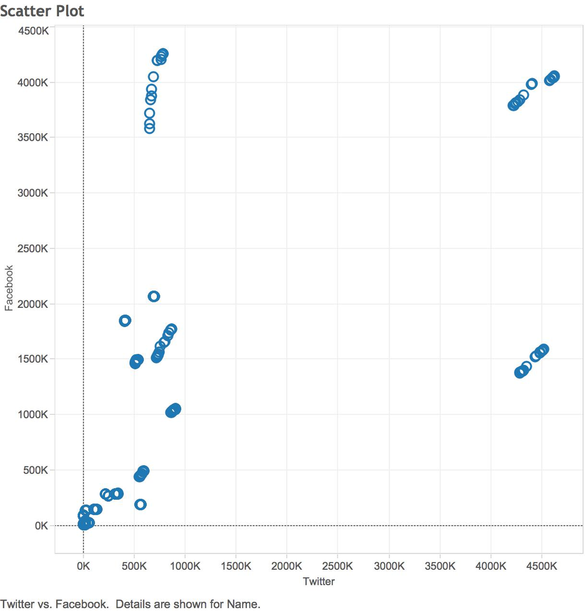

**In R:**

```
##
## > require("jsonlite")
##
## > require("RCurl")
##
## > require(ggplot2)
##
## > require(dplyr)
##
## > require(extrafont)
```

```
## Registering fonts with R
```

```
##
## > df <- data.frame(fromJSON(getURL(URLencode("skipper.cs.utexas.edu:5001/rest/native/?query=\"select * from SOCIALMEDIADATA\""),
## +     httpheader = c .... [TRUNCATED]
##
## > ggplot() + coord_cartesian() + scale_x_continuous() +
## +     scale_y_continuous() + labs(title = "Scatter Plot") + labs(x = "TWITTER",
## +     y = pa .... [TRUNCATED]
```

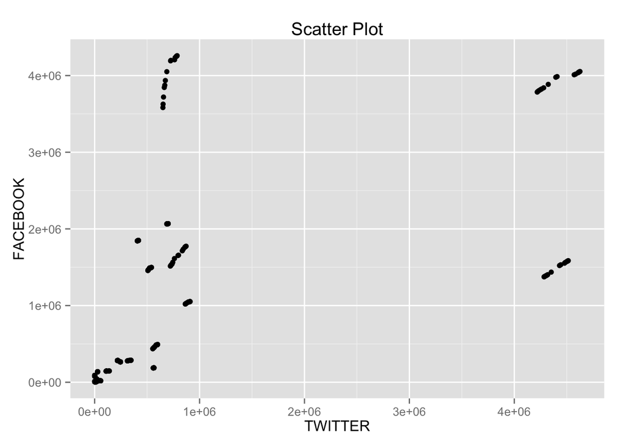

```r
source('~/Desktop/DV_TProject1/01 Data/scatterplot.R', echo = TRUE)
```

### Crosstab

This crosstab shows the amount of Likes each presidential candidate has received. We categorized the candidates by political party, and the orange bars represent the candidates who received more Likes than the ideal amount, which is set at 5,372,686. Anything below that, is less ideal and therefore we consider it a Bad amount of Likes to have

We found it interesting that the leading candidates for each party, both being the only ones with a Good number of Likes, as being Donald Trump and Hilary Clinton. Clinton has been a key part of the government for many years and is therefore very well known, whereas Donald Trump recently chose to participate in the government and has made a very strong social presense.

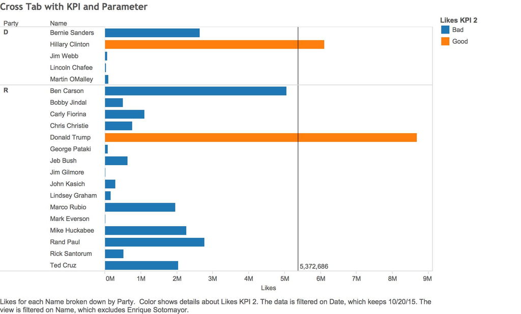

### Bar Chart

This barchart represents four of the presidential candidates–Ben Carson, Donald Trump, Jeb Bush, and Marco Rubio–and compares how popular they each are amongst social media. The orange represents they’re mentioned in an ideal amount of Facebook or Twitter posts, or have an ideal amount of likes. Green indicates that although these numbers aren’t ideal, the candidate is still in a good social media standing. And blue indicates that the candidate isn’t very much noticed amongst social media outlets.

[figure not shown]

**In SQL:**  
**I would first select * from SOCIALMEDIADATA where( (DATE_ = ‘10/20/15’) and (NAME_ = ‘Ben Carson’ or NAME_ = ‘Donald Trump’ or NAME_ = ‘Jeb Bush’ or NAME_ = ‘Marco Rubio’))**  
**Then I would define the KPI exactly as I did on Tableau; If likes > 2M -> Good; Elif likes > 1M -> Okay; Else -> Bad; End**